# Geomorphometric Analysis

Stephanie Martinez

2020

## Geomorphometric analysis

Here I present the code used in my geometric morphometric analysis. The morphometry (body and head views) of each species was analyzed separately. Thus, the markdown sections will be structure as such.

### Packages and data

Load .tps files that contains coordinate data, and a classifier dataframe containing environmental variables and location information (e.g. year, lake name, species (sp), temperature)

```r
library("geomorph")
library("tidyr")
library("dplyr")
library("artyfarty")
library("ggpubr")
library("ggplot2")
library("ggplotify")
library("borealis")
```

**Abbreviations:**

- epun = *Exyrias puntang* ; ajan = *Acentrogobius janthinopterus*
- bepun = body *E. puntang ;* bajan = body *A. janthinopterus*
- hepun = head *E. puntang ;* hajan = head A. janthinopterus

```r
body_epun <- readland.tps("data/body_epun.TPS", specID = "ID", warnmsg =T)
body_ajan <- readland.tps("data/body_ajan.TPS", specID = "ID", warnmsg =T)
head_epun <- readland.tps("data/head_epun.TPS", specID = "ID", warnmsg =T)
head_ajan <- readland.tps("data/head_ajan.TPS", specID = "ID", warnmsg =T)

class <- read.csv("data/classifiers.csv", header=T, dec=".", sep = ";") %>%
  filter(sp!="nd") #remove nd (not identified) specimens
```

## *1- Exyrias puntang*

Adapt and clean the classifiers data frame to *E. puntang* .tps data structure

```r
class_epun <- class %>%
  filter(sp!="sp2") %>%
  filter(!grepl('WAR04_G7_L1', ID)) %>% #outlier - removed
  droplevels()
```

### Superimposition of raw coordinates

```r
#Body
bepun_gpagen <- gpagen(body_epun, Proj=TRUE, print.progress = FALSE)
pdf(file="figures/procrustes_bepun.pdf")
plot(bepun_gpagen)
title(main="Body E.puntang procrustes")
dev.off()
```

```r
#Head
hepun_gpagen <- gpagen(head_epun, Proj=TRUE, print.progress = FALSE)
pdf(file="figures/procrustes_hepun.pdf")
plot(hepun_gpagen)
title(main="Head E.puntang procrustes")
dev.off()
```

This plots can also be done using ggplot2. The script for this and creating transition animations between shapes can be seen in “supplementary/procrustes_ggplot.Rmd”

### PCA of superimposed coordinates

The PCA analysis was done using *geomorph*. Plotting was done by extracting values from the test and using *ggplot2.*

First, the PCA analysis by creating a gm.prcomp object

```r
pca_bepun <- gm.prcomp(bepun_gpagen$coords)
pca_hepun <- gm.prcomp(hepun_gpagen$coords)
```

**Update (2022): Morphospace plot generation in ggplot style has been updated by using the package “borealis”. It is an easier way to generate the plots, with the option of adding convex hull polygons and warp grids. The old (and more manual) ggplot code can still be found at the end of script

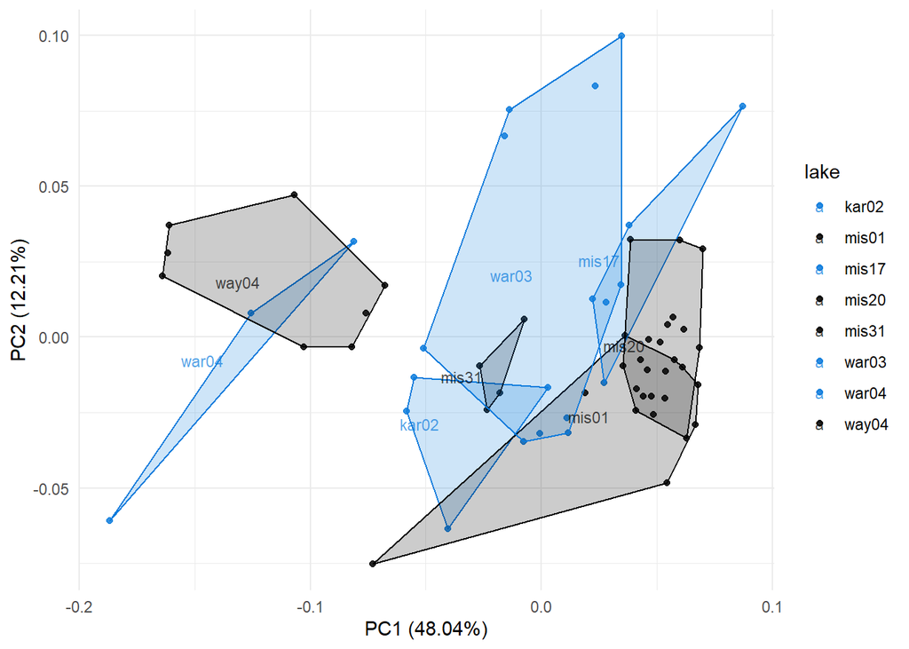

```r
shape.space(pca_hepun, group = class_epun$lake,
            group.title = 'lake',
            convex.hulls = TRUE,
            color = c("#0C7BDC","#000000","#0C7BDC","#000000","#000000","#0C7BDC","#0C7BDC","#000000"),
            group.label.size = 3,
            include.legend = TRUE,
            save.as = "figures/SVG_composite/pca_head_epuntang.pdf",
            height = 8, width = 13)
```

```r
# Plot with warp grids - The grids overlap with the rest of the plot, so I used this code to extract the grids afterwards with Illustrator

shape.space(pca_hepun, group = class_epun$lake, group.title = 'lake', convex.hulls = TRUE,
            color = c("#0C7BDC","#000000","#0C7BDC","#000000","#000000","#0C7BDC","#0C7BDC","#000000"),
            group.label.size = 3,
            backtransform.examples = TRUE,
            ref.shape = hepun_gpagen$consensus,
            shape.method = "TPS",
            bt.links = "none",
            lm.labels = FALSE,
            bt.margin.factor = 4,
            bt.inset.size = 0.35,
            save.as = "figures/SVG_composite/head_epuntang_PCAwarps.pdf",
            width = 13, height = 8)
```

## *2- Acentrogobius janthinopterus*

For this species, we followed the same process a describe before for *Exyrias puntang*

```r
class_ajan <- class %>%
  filter(sp!="sp1") %>%
  filter(!grepl('KAR02', ID)) %>%
  droplevels()
```

### Superimposition of raw coordinates

```r
#Body
bajan_gpagen <- gpagen(body_ajan, Proj=TRUE, print.progress = FALSE)
pdf(file="figures/procrustes_bajan.pdf")
plot(bajan_gpagen)
title(main="Body A.janthinopterus procrustes")
dev.off()
```

```r
#Head
hajan_gpagen <- gpagen(head_ajan, Proj=TRUE, print.progress = FALSE)
pdf(file="figures/procrustes_hajan.pdf")
plot(hajan_gpagen)
title(main="Head A. janthinopterus procrustes")
dev.off()
```

### PCA of superimposed coordinates

PCA analysis

```r
pca_bajan <- gm.prcomp(bajan_gpagen$coords)
pca_hajan <- gm.prcomp(hajan_gpagen$coords)
```

PCA and warp grids plots

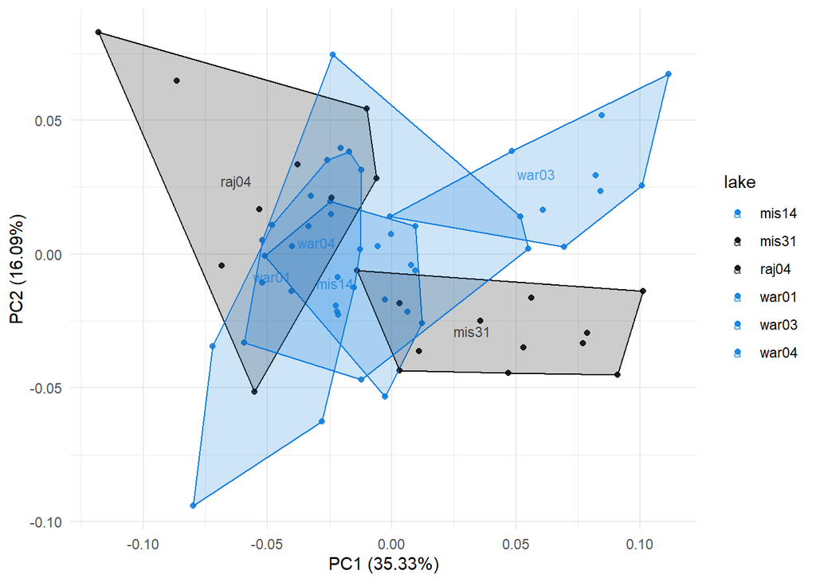

```r
shape.space(pca_hajan, group = class_ajan$lake,
            group.title = 'lake',
            convex.hulls = TRUE,
            color = c("#0C7BDC","#000000","#000000","#0C7BDC","#0C7BDC","#0C7BDC"),
            group.label.size = 3,
            include.legend = TRUE,
            save.as = "figures/SVG_composite/pca_head_ajanthinopterus.pdf",
            height = 8, width = 13)
```

```r
# Plot to extract warp grids (same as previous species)

shape.space(pca_hajan, group = class_ajan$lake, group.title = 'lake', convex.hulls = TRUE,
            color = c("#0C7BDC","#000000","#000000","#0C7BDC","#0C7BDC","#0C7BDC"),
            group.label.size = 3,
            backtransform.examples = TRUE,
            ref.shape = hajan_gpagen$consensus,
            shape.method = "TPS",
            bt.links = "none",
            lm.labels = FALSE,
            bt.margin.factor = 4,
            bt.inset.size = 0.35,
            save.as = "figures/SVG_composite/head_ajanthinopterus_PCAwarps.pdf",
            width = 13, height = 8)
```

## 3- Statistical analyses

### MANOVA

To test if there were differences in the morphology of these species across lakes, a MANOVA test was performed using *ProcD.lm*

First, the superimposed coordinate data has to be arrange as a data frame

```r
#Exyrias puntang
gdf_bepun <- geomorph.data.frame(bepun_gpagen,
                                lake = class_epun$lake,
                                conn = class_epun$connec,
                                temp = class_epun$temp)

gdf_hepun <- geomorph.data.frame(hepun_gpagen,
                                lake = class_epun$lake,
                                conn = class_epun$connec,
                                temp = class_epun$temp)

# Acentrogobius janthinopterus
gdf_bajan <- geomorph.data.frame(bajan_gpagen,
                               lake = class_ajan$lake,
                               conn = class_ajan$connec,
                               temp = class_ajan$temp)
gdf_hajan <- geomorph.data.frame(bajan_gpagen,
                               lake = class_ajan$lake,
                               conn = class_ajan$connec,
                               temp = class_ajan$temp)
```

MANOVAs using each lake and connectivity levels as grouping factors.

**Note:** RRPP uses randomize raw values

```r
# Exyrias puntang
fit1_bepun <- procD.lm(bepun_gpagen$coords ~ lake,
                      data = gdf_bepun, iter = 999,
                      RRPP = FALSE, print.progress = FALSE)
fit2_bepun <- procD.lm(bepun_gpagen$coords ~ conn,
                     data = gdf_bepun, iter = 999,
                     RRPP = FALSE, print.progress = FALSE)
fit3_hepun <- procD.lm(hepun_gpagen$coords ~ lake,
                      data = gdf_hepun, iter = 999,
                      RRPP = FALSE, print.progress = FALSE)
fit4_hepun <- procD.lm(hepun_gpagen$coords ~ conn,
                     data = gdf_hepun, iter = 999,
                     RRPP = FALSE, print.progress = FALSE)
summary(fit1_bepun)
summary(fit2_bepun)
summary(fit3_hepun)
summary(fit4_hepun)

# Acentrogobius janthinopterus
fit1_bajan <- procD.lm(bajan_gpagen$coords ~ lake,
                     data = gdf_bajan, iter = 999,
                     RRPP = FALSE, print.progress = FALSE)
fit2_bajan <- procD.lm(bajan_gpagen$coords ~ conn,
                     data = gdf_bajan, iter = 999,
                     RRPP = FALSE, print.progress = FALSE)
fit3_hajan <- procD.lm(hajan_gpagen$coords ~ lake,
                     data = gdf_hajan, iter = 999,
                     RRPP = FALSE, print.progress = FALSE)
fit4_hajan <- procD.lm(hajan_gpagen$coords ~ conn,
                     data = gdf_hajan, iter = 999,
                     RRPP = FALSE, print.progress = FALSE)
summary(fit1_bajan)
summary(fit2_bajan)
summary(fit3_hajan)
summary(fit4_hajan)
```

### Post-hoc Pairwise test

To see which lakes where contributing to the differences in morphology, we performed a post-hoc pairwise test from the RRP package.

The test uses *“dist”* which is the distance between LS means. By specifying a confidence level, we are given upper confidence limits (UCL) from the distributions of pairwise distances.

```r
# Exyrias puntang
PW_bepun <- pairwise(fit1_bepun, groups = gdf_bepun$lake)
summary(PW_bepun, test.type = "dist", confidence = 0.95, stat.table = FALSE)
PW_hepun <- pairwise(fit3_hepun, groups = gdf_hepun$lake)
summary(PW_hepun, test.type = "dist", confidence = 0.95, stat.table = FALSE)
# Acentrogobius janthinopterus
PW_bajan <- pairwise(fit1_bajan, groups = gdf_bajan$lake)
summary(PW_bepun, test.type = "dist", confidence = 0.95, stat.table = FALSE)
PW_hajan <- pairwise(fit3_hajan, groups = gdf_hajan$lake)
summary(PW_hepun, test.type = "dist", confidence = 0.95, stat.table = FALSE)
```

## Generating morphospace plots with ggplot (old code)

Old version of plots in ggplot version, and with each lake in a different color and shape.

### *Exyrias puntang*

We can extract the values needed for plotting the morphospace using *ggplot2.* We also set classifiers (grouping factors) as factors for our plot.

```r
#Grouping factors
lakes_epun <- as.factor(class_epun[,3])
conn_epun <- as.factor(class_epun[,6])
#extracting PCA component values for plot
comp.bepun <- as.data.frame(pca_bepun$x) %>%
  dplyr::select(Comp1, Comp2)
comp.hepun <- as.data.frame(pca_hepun$x) %>%
  dplyr::select(Comp1, Comp2)
#extracting PCA variance for plot axis
a1 <- summary(pca_bepun) #make the summary an object to extract information
axis1 <- as.data.frame(a1$PC.summary) %>%
  dplyr::select(Comp1,Comp2) %>%
  mutate(Comp1 = Comp1*100, Comp2 = Comp2*100)
a2 <- summary(pca_hepun)
axis2 <- as.data.frame(a2$PC.summary) %>%
  dplyr::select(Comp1,Comp2) %>%
  mutate(Comp1 = Comp1*100, Comp2 = Comp2*100)

#Preparing convex hull matrix
env_epun <- class_epun %>%
  select(lake, connec)

comp.bepun1 <- as.data.frame(pca_bepun$x) %>%  #Body
  dplyr::select(Comp1, Comp2) %>%
  bind_cols(.,env_epun)

comp.hepun1 <- as.data.frame(pca_hepun$x) %>%  #Head
  dplyr::select(Comp1, Comp2) %>%
  bind_cols(.,env_epun)

hull_hepun <- comp.hepun1 %>% #convex hull matrix head
  drop_na() %>%
  group_by(lake) %>%
  slice(chull(Comp1, Comp2))

hull_bepun <- comp.bepun1 %>% #convex hull matrix body
  drop_na() %>%
  group_by(lake) %>%
  slice(chull(Comp1, Comp2))
```

Finally, we can produce a plot using *ggplot*

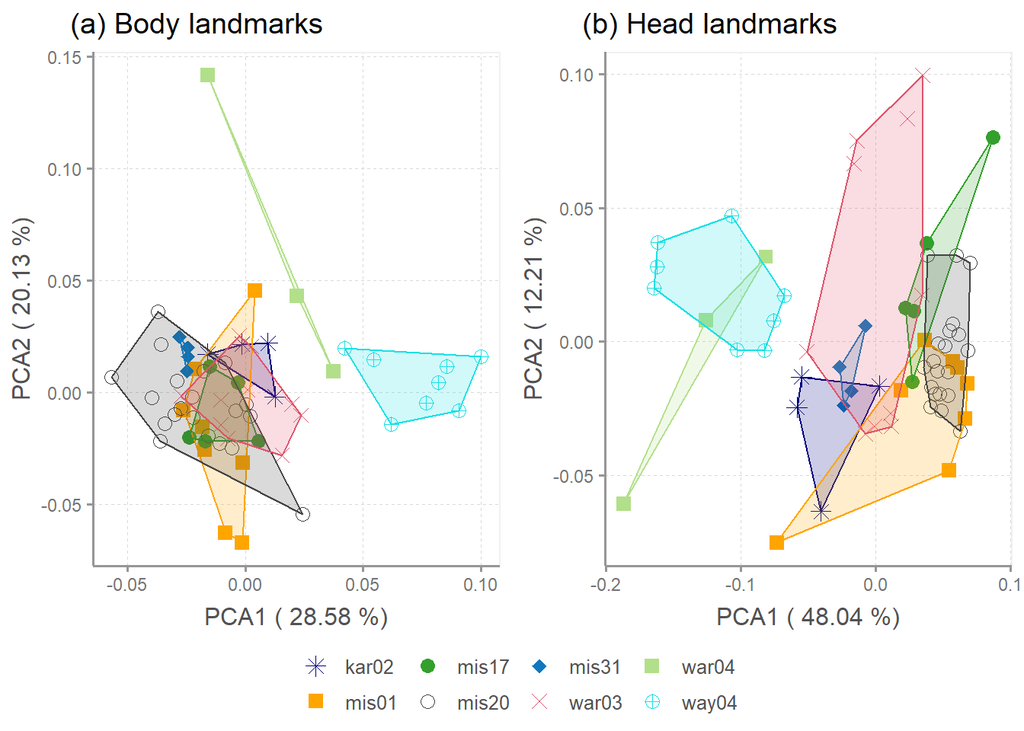

```r
#Body
plot_bepun <- ggplot()+
  theme_scientific()+
  geom_point(data=comp.bepun,
             aes(x = Comp1,
                 y = Comp2,
                 color =lakes_epun,
                 shape= lakes_epun), size = 3) +
  scale_color_manual(breaks=c("kar02","mis01","mis17","mis20","mis31","war03","war04","way04"),
                     values = c("#000080","#ffa500","#33A02C","#474444","#1078bf","#df546c","#B2DF8A","#1be0e4")) +
  scale_shape_manual(breaks=c("kar02","mis01","mis17","mis20","mis31","war03","war04","way04"),
                     values=c(8,15,16,1,18,4,15,10))+
  theme(legend.position = "bottom", legend.title = element_blank())+
  labs(x=paste("PCA1 (",round(axis1$Comp1[2],2),"%)"),
       y =paste("PCA2 (",round(axis1$Comp2[2],2),"%)")) +
  ggtitle("(a) Body landmarks")+
  theme(plot.title = element_text(hjust = -0.15))+
   geom_polygon(data = hull_bepun,
               aes(x = Comp1,
                   y=, Comp2,
                   fill = lake,
                   colour = lake),
               alpha = 0.2,
               show.legend = FALSE) +
  scale_fill_manual(breaks=c("kar02","mis01","mis17","mis20","mis31","war03","war04","way04"),
                    values = c("#000080","#ffa500","#33A02C","#474444","#1078bf","#df546c","#B2DF8A","#1be0e4"))

#Head
plot_hepun <- ggplot()+
  theme_scientific()+
  geom_point(data=comp.hepun,
             aes(x = Comp1,
                 y = Comp2,
                 color =lakes_epun,
                 shape= lakes_epun), size = 3) +
  scale_color_manual(breaks=c("kar02","mis01","mis17","mis20","mis31","war03","war04","way04"),
                     values = c("#000080","#ffa500","#33A02C","#474444","#1078bf","#df546c","#B2DF8A","#1be0e4")) +
  scale_shape_manual(breaks=c("kar02","mis01","mis17","mis20","mis31","war03","war04","way04"),
                     values=c(8,15,16,1,18,4,15,10))+
  theme(legend.position = "bottom", legend.title = element_blank())+
  labs(x=paste("PCA1 (",round(axis2$Comp1[2],2),"%)"),
       y =paste("PCA2 (",round(axis2$Comp2[2],2),"%)")) +
  ggtitle("(b) Head landmarks")+
  theme(plot.title = element_text(hjust = -0.15))+
  geom_polygon(data = hull_hepun,
               aes(x = Comp1,
                   y=, Comp2,
                   fill = lake,
                   colour = lake),
               alpha = 0.2,
               show.legend = FALSE) +
  scale_fill_manual(breaks=c("kar02","mis01","mis17","mis20","mis31","war03","war04","way04"),
                    values = c("#000080","#ffa500","#33A02C","#474444","#1078bf","#df546c","#B2DF8A","#1be0e4"))



#Combined Plot
ggarrange(plot_bepun, plot_hepun, common.legend=TRUE, legend = "bottom")
```

```r
ggsave("figures/geomorph_pca_epun.pdf", width = 13, height = 8)
```

To select and pick warp grids in the PCA plot, you can use the function *picknplot*.*shape* from the package *geomorph*. However, these warps can only be extracted from a plot that uses the *plot* function. On the console, you can choose whether to select another point in the plot, and if you wish to save it as a .png image. See example bellow.

```r
#Body warps
warp_bepun <- plot(pca_bepun, main="Body PCA Exyrias puntang", warpgrids=TRUE)
points(pca_bepun$x,pch=19, col=conn_epun) #can also color by lake lakes_epun
legend("topleft", levels(conn_epun), pch=19, col=1:8) #can also be lakes_epun
picknplot.shape(warp_bepun) #select warp grid in PCA plot

#Head warps
warp_hepun <- plot(pca_hepun, main="Head PCA Exyrias puntang", warpgrids=TRUE)
points(pca_hepun$x,pch=19, col=conn_epun, labels = lakes_epun)
legend("topleft", levels(conn_epun), pch=19, col=1:8)
picknplot.shape(warp_hepun) #select warp grid in PCA plot
```

### Acentrogobius janthinopterus

We follow the same steps for the other species.

```r
#Grouping factors
lakes_ajan <- as.factor(class_ajan[,3])
conn_ajan <- as.factor(class_ajan[,6])
#extracting PCA component values for plot
comp.bajan <- as.data.frame(pca_bajan$x) %>%
  dplyr::select(Comp1, Comp2)
comp.hajan <- as.data.frame(pca_hajan$x) %>%
  dplyr::select(Comp1, Comp2)
#extracting PCA variance for plot axis
a3 <- summary(pca_bajan) #make the summary an object to extract information
axis3 <- as.data.frame(a3$PC.summary) %>%
  dplyr::select(Comp1,Comp2) %>%
  mutate(Comp1 = Comp1*100, Comp2 = Comp2*100)
a4 <- summary(pca_hajan)
axis4 <- as.data.frame(a4$PC.summary) %>%
  dplyr::select(Comp1,Comp2) %>%
  mutate(Comp1 = Comp1*100, Comp2 = Comp2*100)

#Preparing convex hull matrix
env_ajan <- class_ajan %>%
  select(lake, connec)

comp.bajan1 <- as.data.frame(pca_bajan$x) %>%  #Body
  dplyr::select(Comp1, Comp2) %>%
  bind_cols(.,env_ajan)

comp.hajan1 <- as.data.frame(pca_hajan$x) %>%  #Head
  dplyr::select(Comp1, Comp2) %>%
  bind_cols(.,env_ajan)

hull_hajan <- comp.hajan1 %>% #convex hull matrix head
  drop_na() %>%
  group_by(lake) %>%
  slice(chull(Comp1, Comp2))

hull_bajan <- comp.bajan1 %>% #convex hull matrix body
  drop_na() %>%
  group_by(lake) %>%
  slice(chull(Comp1, Comp2))
```

Finally, we can produce a plot using *ggplot* for *Acentrogobius janthinopterus*

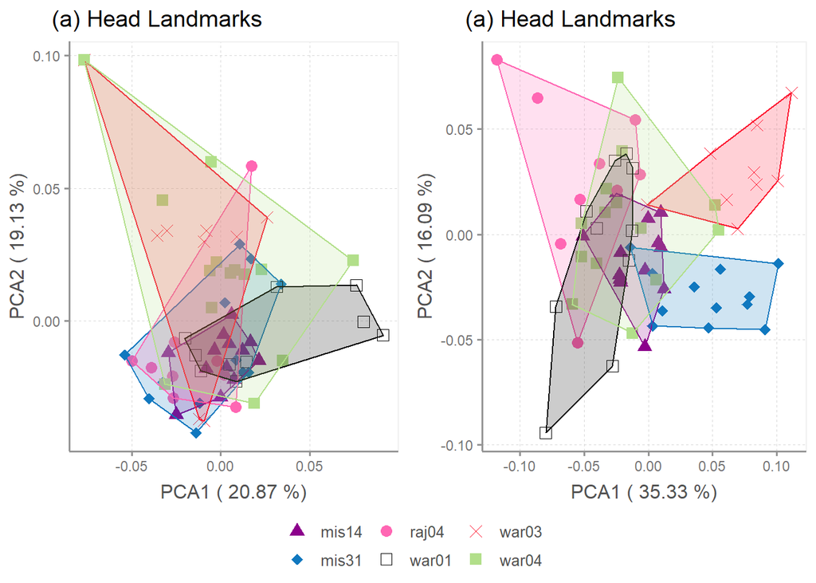

```r
#Body
plot_bajan <- ggplot()+
  theme_scientific()+
  geom_point(data=comp.bajan,
             aes(x = Comp1,
                 y = Comp2,
                 color =lakes_ajan,
                 shape= lakes_ajan), size = 3) +
  scale_color_manual(breaks=c("mis14","mis31","raj04","war01","war03","war04"),
                     values=c("#8c008c","#1078bf","#ff66b3","#000000","#fd1530","#B2DF8A")) +
  scale_shape_manual(breaks=c("mis14","mis31","raj04","war01","war03","war04"),
                     values=c(17,18,16,0,4,15))+
  theme(legend.position = "bottom", legend.title = element_blank())+
  labs(x=paste("PCA1 (",round(axis3$Comp1[2],2),"%)"),
       y =paste("PCA2 (",round(axis3$Comp2[2],2),"%)"))+
  theme(plot.title = element_text(hjust = -0.15)) +
  ggtitle("(a) Head Landmarks") +
  geom_polygon(data = hull_bajan,
               aes(x = Comp1, y=, Comp2,
                   fill = lake,
                   colour = lake),
               alpha = 0.2,
               show.legend = FALSE) +
  scale_fill_manual(breaks=c("mis14","mis31","raj04","war01","war03","war04"),
                     values=c("#8c008c","#1078bf","#ff66b3","#000000","#fd1530","#B2DF8A"))

#Head
plot_hajan <- ggplot()+
  theme_scientific()+
  geom_point(data=comp.hajan,
             aes(x = Comp1,
                 y = Comp2,
                 color =lakes_ajan,
                 shape= lakes_ajan), size = 3) +
  scale_color_manual(breaks=c("mis14","mis31","raj04","war01","war03","war04"),
                     values=c("#8c008c","#1078bf","#ff66b3","#000000","#fd1530","#B2DF8A")) +
  scale_shape_manual(breaks=c("mis14","mis31","raj04","war01","war03","war04"),
                     values=c(17,18,16,0,4,15))+
  theme(legend.position = "bottom", legend.title = element_blank())+
  labs(x=paste("PCA1 (",round(axis4$Comp1[2],2),"%)"),
       y =paste("PCA2 (",round(axis4$Comp2[2],2),"%)"))+
  ggtitle("(a) Head Landmarks")+
  theme(plot.title = element_text(hjust = -0.15))+
  geom_polygon(data = hull_hajan,
               aes(x = Comp1,
                   y=, Comp2,
                   fill = lake,
                   colour = lake),
               alpha = 0.2,
               show.legend = FALSE) +
  scale_fill_manual(breaks=c("mis14","mis31","raj04","war01","war03","war04"),
                     values=c("#8c008c","#1078bf","#ff66b3","#000000","#fd1530","#B2DF8A"))

# Combined Plot
ggarrange(plot_bajan, plot_hajan, common.legend=TRUE, legend = "bottom")
```

```r
ggsave("figures/geomorph_pca_ajan.pdf", width = 13, height = 8) #svgLite must be installed
```